# Gender Pay Gap - Review of Data Quality

```r
library(tidyverse)
library(here)
library(naniar)
library(finalfit)

# import clean data
paygap <- read_rds(here('gender_paygap/data/processed/paygap_clean.rda'))
```

# Timeliness

Most public authority employers must use a snapshot date of 31 March. They must report and publish their gender pay gap information by 30 March of the following year

Private, voluntary, and all other public authority employers must use a snapshot date of 5 April. They must report and publish their gender pay gap information by 4 April of the following year.

It is a legal requirement for all employers who are required to report and publish their gender pay gap information to accurately report this information. Failing to do this within one year of the snapshot date is unlawful. The Equality and Human Rights Commission has the power to enforce any failure to comply with the regulations. Employers that fail to report on time, or report inaccurate data, will be in breach of the regulations and risk facing enforcement action from the Equality and Human Rights Commission (EHRC), leading to court orders and fines.

```r
paygap %>%
    summarise(min = min(delay),
              mean = mean(delay),
              median = median(delay),
              max = max(delay)) %>%
    round(1)
```

| min | mean | median | max |
| --- | --- | --- | --- |
| -545.6 | -11.7 | -6.5 | 1576.4 |

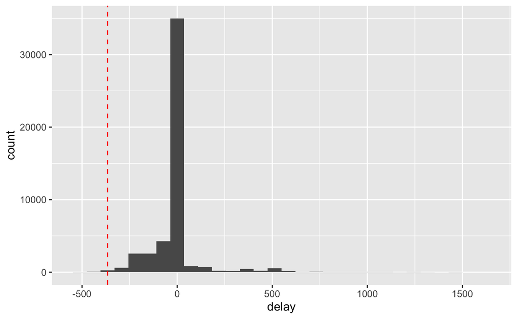

```r
paygap %>%
    ggplot(aes(delay)) +
    geom_histogram(bins = 30, ) +
    geom_vline(xintercept = - 366,
               colour = 'red',
               linetype = 'dashed')
```

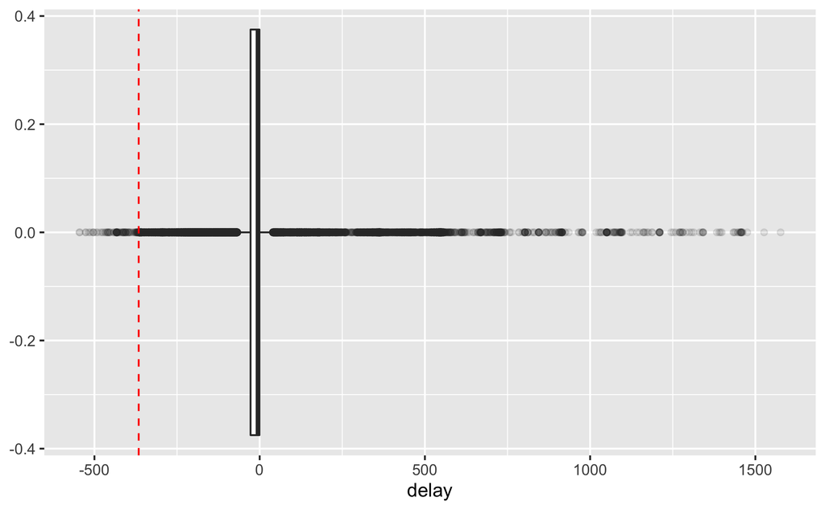

```r
paygap %>%
    ggplot(aes(delay)) +
    geom_boxplot(outlier.alpha = 0.1) +
    geom_vline(xintercept = - 366,
               colour = 'red',
               linetype = 'dashed')
```

```r
sum(paygap$late_submission)
```

```
[1] 6764
```

```r
round(mean(paygap$late_submission) * 100)
```

```
[1] 14
```

```r
length(unique(paygap[paygap$delay < -366, ]$employer_id))
```

```
[1] 96
```

Most employers appear submit their data just before their deadline. However 0n 6764 (~14%) occasions data was submitted late. The data shows that there is evidence of some employers submitting data over 1500 days late. As well as being unlawful long delays could have implications for the accuracy of data.

There were 96 occasions where employers appear to have submitted data over a year before their due date - therefore before their snapshot date. This calls into question the validity of this data.

# Uniqueness

```r
# check for duplication of observations
sum(duplicated(paygap))
```

```
[1] 0
```

```r
# is employer_id a unique identifier
nrow(paygap) / n_distinct(paygap$employer_id)
```

```
[1] 3.830877
```

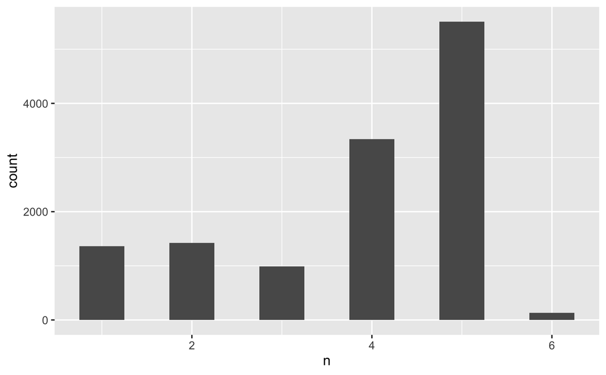

```r
# no there are nearly 4 times as many observations as employer ids

# visualise
paygap %>%
  count(employer_id) %>%
  ggplot() +
  geom_histogram(aes(n), binwidth = 0.5)
```

```r
# most employer ids appear to be associated with multiple records
# is there any evidence of >1 entry by employer in same year
paygap %>%
  group_by(employer_id, year) %>%
  count() %>%
    filter(n > 1) %>%
    nrow()
```

```
[1] 0
```

There are no duplicate records in this data set. There are multiple observations per employer id due to data being submitted across multiple years. There is only one observation per employer id:year pair - making this pairing a unique identifier. There were 4 occasions identified in the raw data where employers had entered 2 submissions for the same year. This was dealt with during data cleaning where only the most recent entry was retained.

# Validity

There were a number of areas to explore around validity of the data

### Early submission

```r
# early data submission

paygap %>%
    filter(delay < -366) %>%
    group_by(snapshot_date) %>%
    summarise(
        n = n(),
        min_delay = min(delay),
        mean_delay = mean(delay),
        max_delay = max(delay)
    )
```

| snapshot_date | n | min_delay | mean_delay | max_delay |
| --- | --- | --- | --- | --- |
| 2020-10-06 | 96 | -545.5575 | -427.6543 | -368.379 |

### Bonus percent

```r
paygap %>%
  select(male_bonus_percent, female_bonus_percent) %>%
 summary()
```

```
 male_bonus_percent female_bonus_percent
 Min.   :  0.0      Min.   :  0.00
 1st Qu.:  0.2      1st Qu.:  0.00
 Median : 19.3      Median : 17.10
 Mean   : 36.2      Mean   : 34.88
 3rd Qu.: 76.4      3rd Qu.: 74.00
 Max.   :100.0      Max.   :100.40
```

```r
paygap %>%
    filter(female_bonus_percent > 100) %>%
    select(current_name, year, female_bonus_percent)
```

| current_name | year | female_bonus_percent |
| --- | --- | --- |
| FIRST TRENITALIA WEST COAST RAIL LIMITED | 2021 | 100.4 |

```r
# one employer reported 100.4% of females received a bonus
```

This refers to the percentage of men and women receiving bonus pay. No values should be less than 0% or greater than 100%. All values were valid except for one employer who reported that 100.4% of women had been paid a bonus in 2021

### Difference in hourly percent

```r
paygap %>%
  select(diff_mean_hourly_percent, diff_median_hourly_percent) %>%
  summary()
```

```
 diff_mean_hourly_percent diff_median_hourly_percent
 Min.   :-499.90          Min.   :-499.5
 1st Qu.:   4.80          1st Qu.:   1.0
 Median :  13.20          Median :   9.9
 Mean   :  14.03          Mean   :  12.2
 3rd Qu.:  22.40          3rd Qu.:  21.6
 Max.   : 159.00          Max.   : 121.2
```

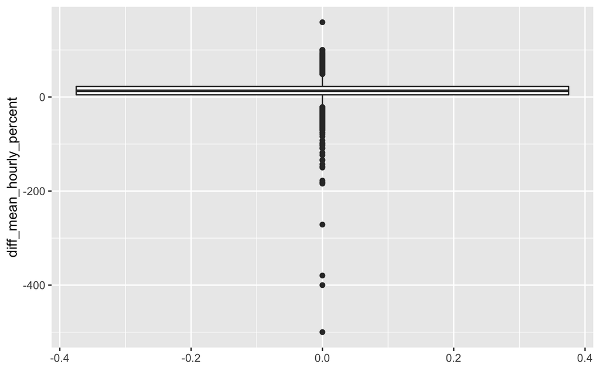

```r
paygap %>%
  ggplot(aes(y = diff_mean_hourly_percent)) +
  geom_boxplot()
```

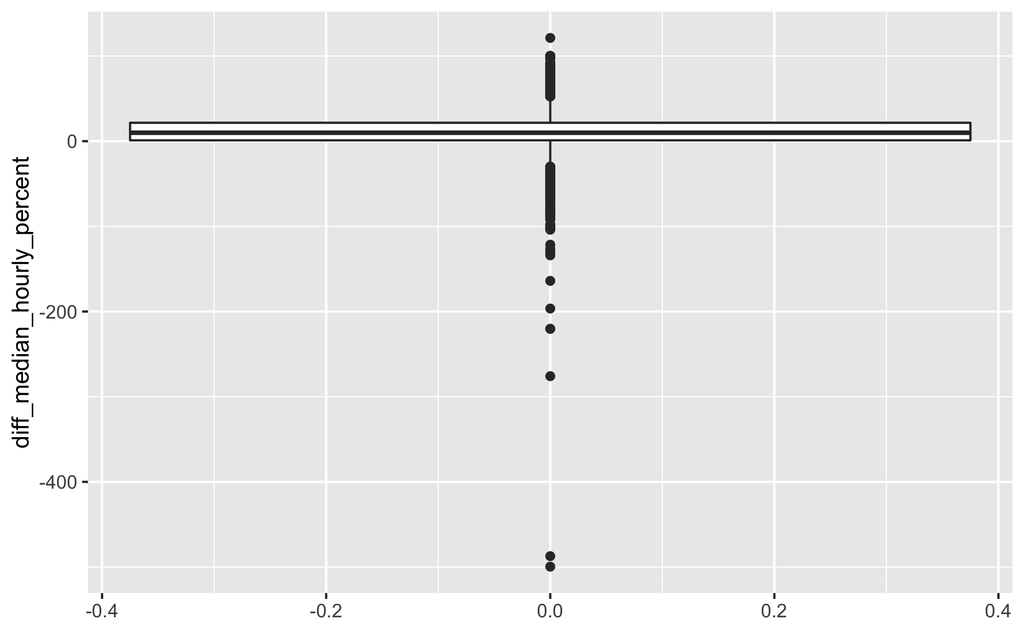

```r
paygap %>%
  ggplot(aes(y = diff_median_hourly_percent)) +
  geom_boxplot()
```

Positive values indicate that males paid more than females per hour whilst negative means that females paid more than males.

The minimum value for median pay difference between males and females was around minus 500% - ie. women paid 5 times more per hour than men. The maximum value was around 120%. There are a number of outlying values - maybe calculate proportion values which are outliers?

### Difference in bonus percent

```r
paygap %>%
  select(diff_mean_bonus_percent, diff_median_bonus_percent) %>%
  summary()
```

```
 diff_mean_bonus_percent diff_median_bonus_percent
 Min.   :-82000.00       Min.   :-120695.0
 1st Qu.:     0.30       1st Qu.:      0.0
 Median :    31.50       Median :     15.5
 Mean   :    17.01       Mean   :     -3.8
 3rd Qu.:    55.70       3rd Qu.:     42.7
 Max.   :  3848.20       Max.   :   4000.0
 NA's   :8979            NA's   :8981
```

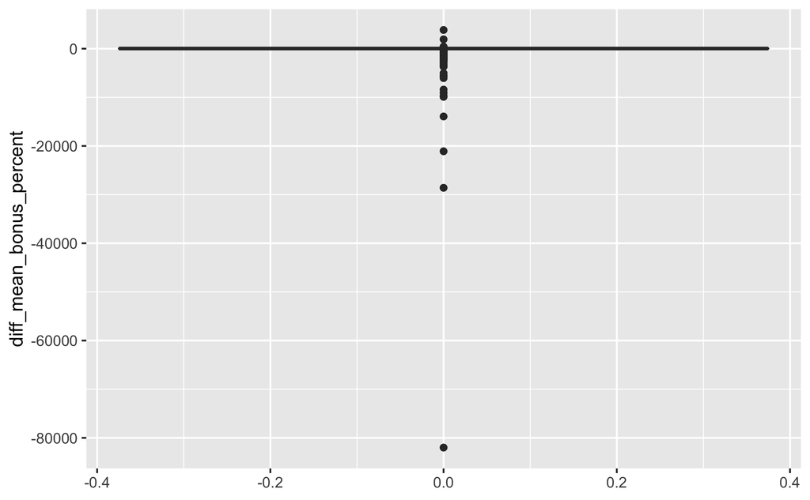

```r
paygap %>%
  ggplot(aes(y = diff_mean_bonus_percent)) +
  geom_boxplot()
```

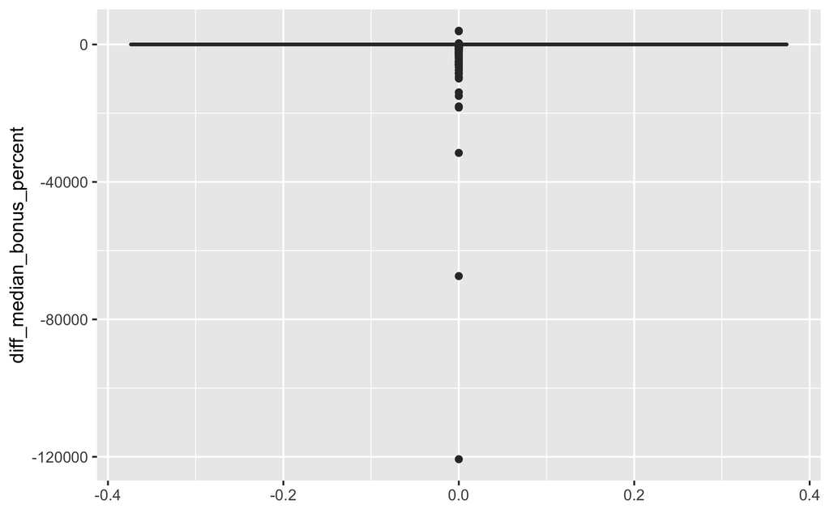

```r
paygap %>%
  ggplot(aes(y = diff_median_bonus_percent)) +
  geom_boxplot()
```

Positive values indicate that males paid more than females as a bonus whilst negative means that females paid more than males.

The minimum value for median pay difference between males and females was around minus 120000 %. The maximum value was 4000%.

These figures are extreme - especially where females paid 120000% more. Explore these employers in more detail. Investigation provides no clear evidence regarding validity - all values are possible. In real world situation these extreme values could be double checked with submitting organisation.

## Hourly pay quartiles

```r
paygap %>%
  select(contains('quartile')) %>%
  summary()
```

```
 male_lower_quartile female_lower_quartile male_lower_middle_quartile female_lower_middle_quartile
 Min.   :  0.00      Min.   :  0.00        Min.   :  0.00             Min.   :  0.00
 1st Qu.: 26.50      1st Qu.: 36.00        1st Qu.: 29.00             1st Qu.: 28.00
 Median : 44.00      Median : 56.00        Median : 48.00             Median : 52.00
 Mean   : 45.76      Mean   : 54.24        Mean   : 50.11             Mean   : 49.89
 3rd Qu.: 64.00      3rd Qu.: 73.50        3rd Qu.: 72.00             3rd Qu.: 71.00
 Max.   :100.00      Max.   :100.00        Max.   :100.00             Max.   :100.00
 NA's   :397         NA's   :397           NA's   :397                NA's   :397
 male_upper_middle_quartile female_upper_middle_quartile male_top_quartile female_top_quartile
 Min.   :  0.00             Min.   :  0.00               Min.   :  0.00    Min.   :  0.00
 1st Qu.: 33.30             1st Qu.: 22.00               1st Qu.: 40.90    1st Qu.: 18.20
 Median : 53.20             Median : 46.80               Median : 62.00    Median : 38.00
 Mean   : 54.47             Mean   : 45.53               Mean   : 60.13    Mean   : 39.87
 3rd Qu.: 78.00             3rd Qu.: 66.70               3rd Qu.: 81.80    3rd Qu.: 59.10
 Max.   :100.00             Max.   :100.00               Max.   :100.00    Max.   :100.00
 NA's   :397                NA's   :397                  NA's   :397       NA's   :397
```

```r
# these are percentages and all are valid ie. between 0-100%
# also average male plus average female values = 100% for each quartile
```

All hourly pay quartile data appears to be valid

# Completeness

## Explicit missing data

```r
paygap_selected <-  paygap %>%
    select(-c(company_link_to_gpg_info,
           company_number,
           responsible_person))

paygap_selected %>%
    pct_complete_case()
```

```
[1] 72.9446
```

```r
paygap_selected %>%
    pct_miss_case()
```

```
[1] 27.0554
```

```r
paygap_selected %>%
    pct_miss()
```

```
[1] 1.966665
```

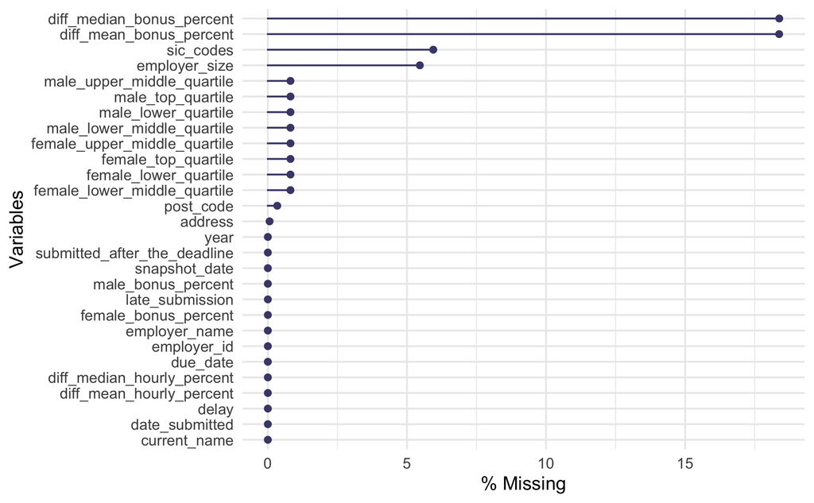

```r
paygap_selected %>%
    gg_miss_var(show_pct = TRUE)
```

When unimportant variables removed from data 73% of rows are complete leaving 27% having some missing data. 2.0% of all data is missing. The most frequent missing data is for difference in bonus percent followed by sic codes, employer size and then hourly pay quartiles.

### Difference in bonus percent

```r
sum(is.na(paygap$diff_median_bonus_percent))
```

```
[1] 8981
```

```r
sum(is.na(paygap$diff_mean_bonus_percent))
```

```
[1] 8979
```

```r
sum(is.na(paygap$male_bonus_percent))
```

```
[1] 0
```

```r
sum(is.na(paygap$female_bonus_percent))
```

```
[1] 0
```

```r
## employers who don't pay a bonus to one or both sexes
paygap %>%
  filter(female_bonus_percent == 0 | male_bonus_percent == 0) %>%
  summarise(missing_mean = sum(is.na(diff_mean_bonus_percent)),
            missing_median = sum(is.na(diff_median_bonus_percent)))
```

| missing_mean | missing_median |
| --- | --- |
| 8971 | 8971 |

```r
# missing values where bonuses are paid to both sexes
paygap %>%
  # select observations where bonuses are paid to males and females but there
  # is still missing data for difference in bonus percent
  filter((female_bonus_percent != 0 & male_bonus_percent != 0) &
           (is.na(diff_median_bonus_percent) | is.na(diff_mean_bonus_percent)
            )
         )%>%
  nrow()
```

```
[1] 14
```

The largest amount of missing data was for percent difference in bonus pay between males and females. There were 8981 observations with missing values. There were no missing values for percentage of male or female employees receiving bonus.

It appears that most of missing values (8971) relate to employers where bonuses were not paid to either (or both) males or females and therefore difference cant be calculated. There were 14 observations where bonuses were paid to males and females but the value for percent difference in bonus pay was missing.

### Hourly pay quartiles

```r
paygap %>%
  select(contains('quartile')) %>%
  summary()
```

```
 male_lower_quartile female_lower_quartile male_lower_middle_quartile female_lower_middle_quartile
 Min.   :  0.00      Min.   :  0.00        Min.   :  0.00             Min.   :  0.00
 1st Qu.: 26.50      1st Qu.: 36.00        1st Qu.: 29.00             1st Qu.: 28.00
 Median : 44.00      Median : 56.00        Median : 48.00             Median : 52.00
 Mean   : 45.76      Mean   : 54.24        Mean   : 50.11             Mean   : 49.89
 3rd Qu.: 64.00      3rd Qu.: 73.50        3rd Qu.: 72.00             3rd Qu.: 71.00
 Max.   :100.00      Max.   :100.00        Max.   :100.00             Max.   :100.00
 NA's   :397         NA's   :397           NA's   :397                NA's   :397
 male_upper_middle_quartile female_upper_middle_quartile male_top_quartile female_top_quartile
 Min.   :  0.00             Min.   :  0.00               Min.   :  0.00    Min.   :  0.00
 1st Qu.: 33.30             1st Qu.: 22.00               1st Qu.: 40.90    1st Qu.: 18.20
 Median : 53.20             Median : 46.80               Median : 62.00    Median : 38.00
 Mean   : 54.47             Mean   : 45.53               Mean   : 60.13    Mean   : 39.87
 3rd Qu.: 78.00             3rd Qu.: 66.70               3rd Qu.: 81.80    3rd Qu.: 59.10
 Max.   :100.00             Max.   :100.00               Max.   :100.00    Max.   :100.00
 NA's   :397                NA's   :397                  NA's   :397       NA's   :397
```

### Employer size

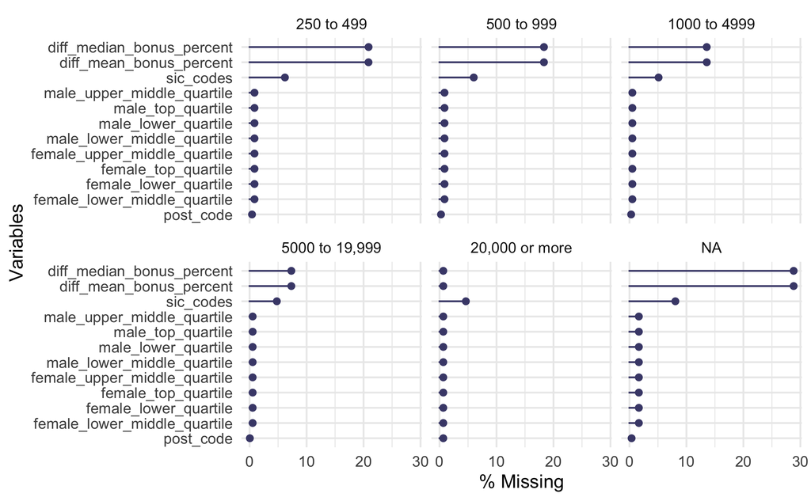

This is an area to revisit prior to any modelling that requires management of missing data.

## Implicit missing data

This is missing data where there is no row in the dataset for a particular employer:year pairing.

Companies with size 250-499 may fall out of reporting requirements due to changes in workforce size or may go out of business.

Missing data submission most likely to be an issue where there are gaps between years of submission esp if a large company that is unlikely to have reduced its workforce to below 250 employees.

| employer_id | snapshot_date | due_date | year | employer_size | gap |
| --- | --- | --- | --- | --- | --- |
| 4 | 2017-04-05 | 2018-04-05 | 2017 | 500 to 999 | NA |
| 4 | 2018-04-05 | 2019-04-05 | 2018 | 1000 to 4999 | 1 |
| 4 | 2019-04-05 | 2020-04-05 | 2019 | 500 to 999 | 1 |
| 4 | 2020-10-06 | 2021-10-06 | 2020 | 500 to 999 | 1 |
| 4 | 2021-04-05 | 2022-04-05 | 2021 | 500 to 999 | 1 |
| 5 | 2017-04-05 | 2018-04-05 | 2017 | 250 to 499 | NA |
| 5 | 2018-04-05 | 2019-04-05 | 2018 | 250 to 499 | 1 |
| 5 | 2020-10-06 | 2021-10-06 | 2020 | 250 to 499 | 2 |
| 5 | 2021-04-05 | 2022-04-05 | 2021 | NA | 1 |
| 6 | 2017-04-05 | 2018-04-05 | 2017 | 500 to 999 | NA |

[output cut: 990 more lines]

Some work to do on interpretation of this data

```r
## accuracy ----

### submitted_after_the_deadline ----

# assess accuracy by comparing with late_submit which has been calculated from
# the dates provided

paygap %>%
  xtabs(~ submitted_after_the_deadline + late_submit, data = .)

## accuracy = total correct / total observations
## ~ 92% accurate - I am unsure why these don't match 100%
## it could be a data collection issue
## plan: replace submitted_after_the_deadline with values from late_submiy

paygap <-
  paygap %>%
  mutate(
    submitted_after_the_deadline = late_submit
  )
```

[output not shown]